# Projekt modele liniowe i mieszane

Zadanie IV

Aleksandra Dąbrowska, Jan Dmitruk, Magda Młynarczyk

30 kwietnia 2017

# Cel

Celem czwartego etapu projektu jest wizualizacja modelu z etapu trzeciego, czyli opartego na cechach zadania i ucznia.

# Transformacje zmiennej objaśnianej

W poprzednim etapie korzystaliśmy z logarytmicznego przekształcenia zmiennej objaśnianej, sprawdzimy teraz czy transformacje z rodziny Boxa-Coxa poprawią jakość naszego modelu.

```r
load("dane_nowe.rda")

model_4 <- lm(log(czas_zadania)~zadanie*pozycja_zadania+id_kwestionariusza+plec+mies_ur+id_kraju+wyk_m+wyk_o+gr_zawod_m+gr_zawod_o+stat_m+stat_o, data = dane_nowe)

wsp <- boxcox(model_4, lambda = seq(-2, 4, 1/10))
```

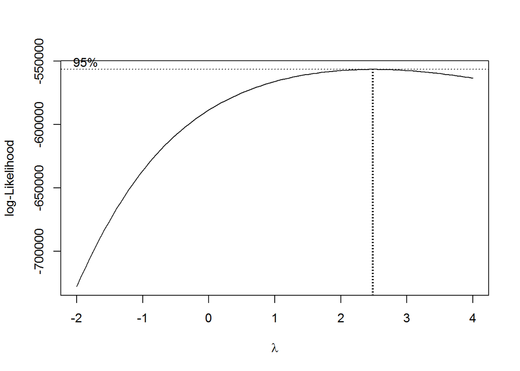

```r
wsp <- wsp$x[which.max(wsp$y)]

model_4_box <- lm((czas_zadania)^wsp~zadanie*pozycja_zadania+id_kwestionariusza+plec+mies_ur+id_kraju+wyk_m+wyk_o+gr_zawod_m+gr_zawod_o+stat_m+stat_o, data = dane_nowe)
```

```r
kable(rsq)
```

|  | R squared |
| --- | --- |
| model_4 | 0.5035688 |
| model_4_box | 0.3560456 |

Wartość R-squared jest zdecydowanie lepsza dla wybranego wcześniej logarytmu.

# Diagnostyka modelu

## Wykresy diagnostyczne dla wybranego modelu

Dla `model_4` wykonujemy wykresy diagnostyczne.

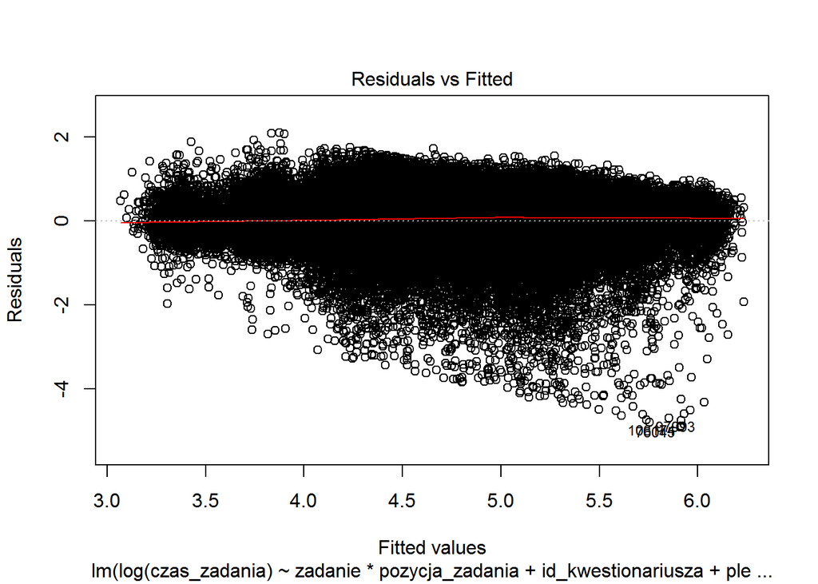

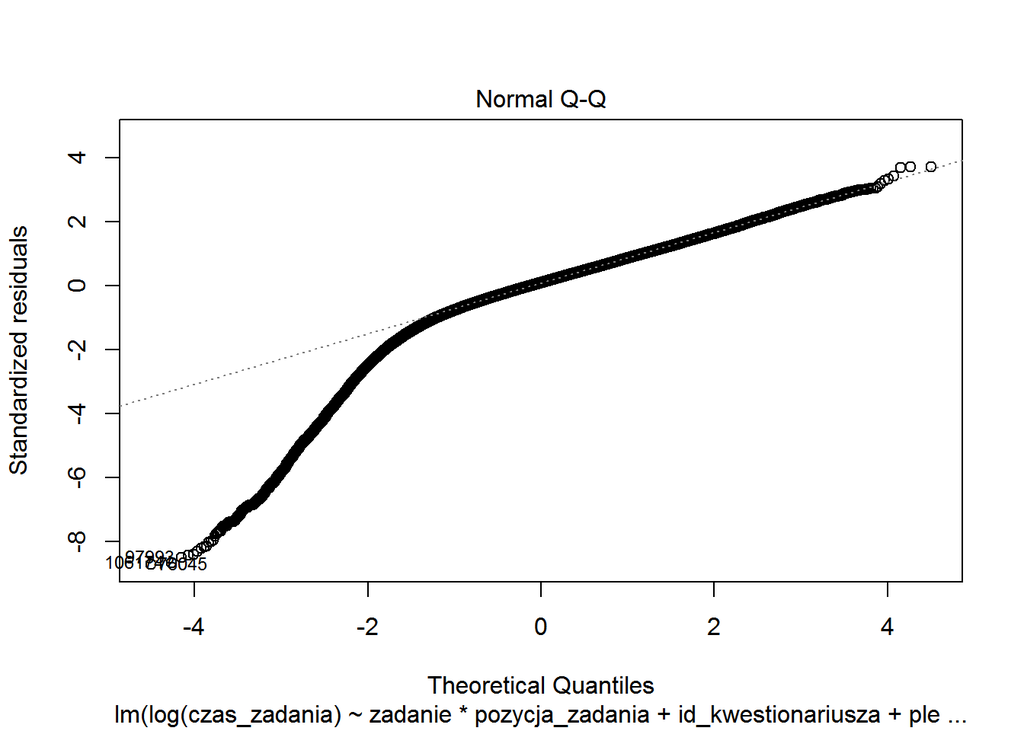

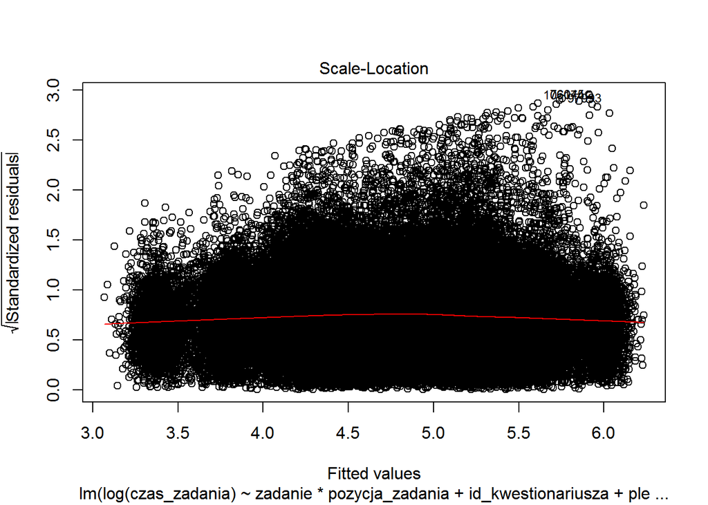

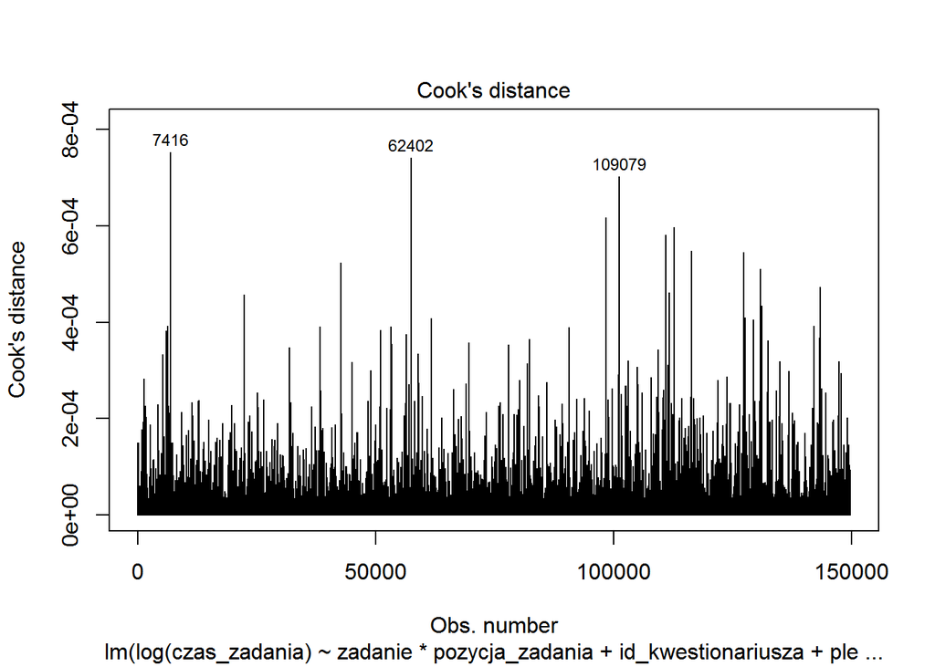

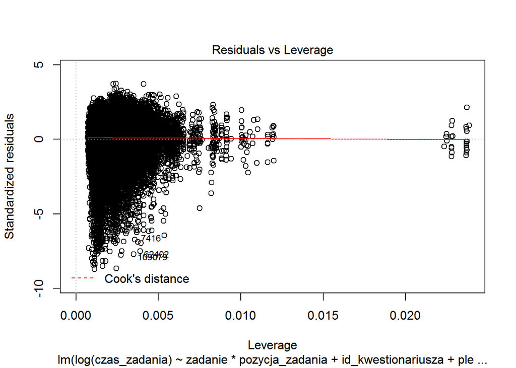

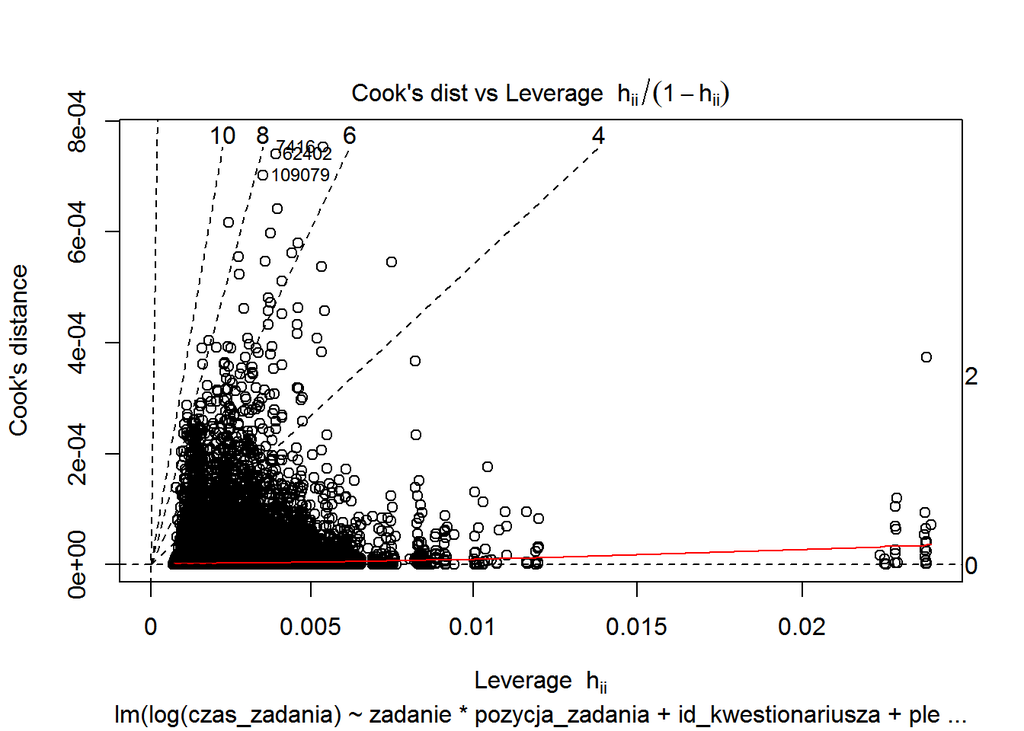

```r
plot(model_4, which = c(1:6))
```

Na wykresach widzimy, że nasz model pozytywnie przechodzi wykresy diagnostyczne z wyjątkiem wykresu `Q-Q Normal`, co może świadczyć, że reszty nie mają rozkładu normalnego.